# ¿Qué factores influyen en la participación ciudadana peruana?

```r
library(rmdformats)
library(rio)
data<- import("Peru LAPOP AmericasBarometer 2019 v1.0_W.dta")
```

> #VARIABLE DEPENDIENTE:

Participación ciudadana, se divide en 3 variables que compararemos juntas y separadas

*PARTICIPACIÓN CIUDADANA EN VIAS LEGALES*

Es decir, participa tal como la constitución dice, por meedio de referendun, acopio a las instituciones estatales, etc.

¿Ha asistido a un cabildo abierto o una sesión municipal durantelos últimos 12 meses?

```r
str(data$np1)
```

```
##  num [1:1521] 2 2 2 2 2 1 1 2 2 2 ...
##  - attr(*, "label")= chr "Asistencia a una reunión municipal"
##  - attr(*, "format.stata")= chr "%36.0f"
##  - attr(*, "labels")= Named num [1:5] 1 2 NA NA NA
##   ..- attr(*, "names")= chr [1:5] "Sí" "No" "No sabe" "No responde" ...
```

```r
table(data$np1)
```

```
##
##    1    2
##  184 1330
```

```r
data$reunion_municipal <- as.factor(data$np1)
levels(data$reunion_municipal)=c("Asiste","No Asiste")
table(data$reunion_municipal)
```

```
##
##    Asiste No Asiste
##       184      1330
```

Por favor, dígame si usted asiste a las reuniones de estas organizaciones por lo menos una vez a la semana, una o dos veces al mes, una o dos veces al año, o nunca. ¿Reuniones de un comité o junta de mejoras para la comunidad? Asiste…

```r
table(data$cp8)
```

```
##
##   1   2   3   4
##  62 234 306 898
```

```r
data$junta=car::recode(data$cp8, "4=1;3=2;2=3;1=4")
data$junta=as.ordered(data$junta)
levels(data$junta)=c("Nunca","Una o dos veces al año", "Una o dos veces al mes","Una vez a la semana")
table (data$junta)
```

```
##
##                  Nunca Una o dos veces al año Una o dos veces al mes
##                    898                    306                    234
##    Una vez a la semana
##                     62
```

*PARTICIPACIÓN CIUDADANA EN POLÍTICA (Partidos políticos)*

Por favor, dígame si usted asiste a las reuniones de estas organizaciones por lo menos una vez a la semana, una o dos veces al mes, una o dos veces al año, o nunca. ¿Reuniones de un partido o movimiento político? Asiste…

```r
table(data$cp13)
```

```
##
##    1    2    3    4
##   22   62  168 1251
```

```r
data$junta_partido=car::recode(data$cp13, "4=1;3=2;2=3;1=4")
data$junta_partido=as.ordered(data$junta_partido)
levels(data$junta_partido)=c("Nunca","Una o dos veces al año", "Una o dos veces al mes","Una vez a la semana")
table(data$junta_partido)
```

```
##
##                  Nunca Una o dos veces al año Una o dos veces al mes
##                   1251                    168                     62
##    Una vez a la semana
##                     22
```

*PARTICIPACIÓN CIUDADANA CON CREENCIAS INDIVIDUALES:*

¿En los últimos 12 meses ha participado en una manifestación o protesta pública?

```r
str(data$prot3)
```

```
##  num [1:1521] 2 2 2 2 2 2 1 2 2 2 ...
##  - attr(*, "label")= chr "Participó en una protesta"
##  - attr(*, "format.stata")= chr "%36.0f"
##  - attr(*, "labels")= Named num [1:4] 1 2 NA NA
##   ..- attr(*, "names")= chr [1:4] "Sí ha participado" "No ha participado" "No responde" "No Aplica"
```

```r
data$prot3 <- as.factor(data$prot3)
table(data$prot3)
```

```
##
##    1    2
##  217 1303
```

```r
levels(data$prot3)=c("Sí ha participado","No ha participado")
```

> #VARIABLES INDEPENDIENTES DE PRIMER BLOQUE

**Confianza Política**

Según el codebook la codificación de la variable va de 1 a 7, en ese orden de menor a mayor.

*Confianza en instituciones políticas y partidos políticos*

Se hará un índice de confianza a raiz de la tecnica de reducción de dimensiones Analisis factorial Exploratorio que nos resumira la bateria de variables que tenemos.

VI___ Confianza en el sistema de justicia (b10a), las FFAA (b12), el congreso (b13), la policía nacional (b18), los partidos políticos (b21), el presidente (b21a), la corte supremo de justicia (b31), las municipalidades (b32)

(*)Creación de factores

```r
library(dplyr)
subdata=select(data,"b10a","b12","b13","b18","b21","b21a","b31","b32")
library(dplyr)

subdata=subdata %>%
   rename(C_SistemaJusticia=b10a) %>% rename(C_FFAA=b12) %>% rename(C_congreso=b13) %>% rename(C_Policia=b18) %>% rename(C_partidosPoliticos=b21) %>% rename(C_Presidente=b21a) %>% rename(C_CorteJusticia=b31) %>% rename(C_Municipalidades=b32)

names(subdata)
```

```
## [1] "C_SistemaJusticia"   "C_FFAA"              "C_congreso"
## [4] "C_Policia"           "C_partidosPoliticos" "C_Presidente"
## [7] "C_CorteJusticia"     "C_Municipalidades"
```

```r
subdata[,1:8]=lapply(subdata[,1:8],as.numeric)
str(subdata)
```

```
## 'data.frame':    1521 obs. of  8 variables:
##  $ C_SistemaJusticia  : num  3 5 2 3 3 1 2 4 3 4 ...
##  $ C_FFAA             : num  3 7 5 3 5 3 3 5 4 6 ...
##  $ C_congreso         : num  3 5 1 2 3 1 1 4 1 5 ...
##  $ C_Policia          : num  2 6 1 2 6 4 3 4 5 5 ...
##  $ C_partidosPoliticos: num  2 5 1 3 3 3 1 4 1 4 ...
##  $ C_Presidente       : num  3 6 4 5 5 4 3 5 6 5 ...
##  $ C_CorteJusticia    : num  3 5 4 3 3 2 1 5 3 5 ...
##  $ C_Municipalidades  : num  4 5 5 4 4 3 2 4 2 4 ...
```

```r
summary(subdata)
```

```
##  C_SistemaJusticia     C_FFAA        C_congreso      C_Policia
##  Min.   :1.000     Min.   :1.000   Min.   :1.000   Min.   :1.000
##  1st Qu.:1.000     1st Qu.:3.000   1st Qu.:1.000   1st Qu.:2.000
##  Median :3.000     Median :5.000   Median :2.000   Median :4.000
##  Mean   :2.847     Mean   :4.522   Mean   :2.252   Mean   :3.604
##  3rd Qu.:4.000     3rd Qu.:6.000   3rd Qu.:3.000   3rd Qu.:5.000
##  Max.   :7.000     Max.   :7.000   Max.   :7.000   Max.   :7.000
##  NA's   :12        NA's   :9       NA's   :6       NA's   :4
##  C_partidosPoliticos  C_Presidente   C_CorteJusticia C_Municipalidades
##  Min.   :1.000       Min.   :1.000   Min.   :1.000   Min.   :1.000
##  1st Qu.:1.000       1st Qu.:2.000   1st Qu.:2.000   1st Qu.:2.000
##  Median :2.000       Median :4.000   Median :3.000   Median :3.000
##  Mean   :2.272       Mean   :3.605   Mean   :3.019   Mean   :3.385
##  3rd Qu.:3.000       3rd Qu.:5.000   3rd Qu.:4.000   3rd Qu.:4.000
##  Max.   :7.000       Max.   :7.000   Max.   :7.000   Max.   :7.000
##  NA's   :9           NA's   :8       NA's   :21      NA's   :12
```

```r
subdata[is.na(subdata)] <- 0
summary(subdata)
```

```
##  C_SistemaJusticia     C_FFAA        C_congreso      C_Policia
##  Min.   :0.000     Min.   :0.000   Min.   :0.000   Min.   :0.000
##  1st Qu.:1.000     1st Qu.:3.000   1st Qu.:1.000   1st Qu.:2.000
##  Median :3.000     Median :5.000   Median :2.000   Median :4.000
##  Mean   :2.824     Mean   :4.495   Mean   :2.243   Mean   :3.595
##  3rd Qu.:4.000     3rd Qu.:6.000   3rd Qu.:3.000   3rd Qu.:5.000
##  Max.   :7.000     Max.   :7.000   Max.   :7.000   Max.   :7.000
##  C_partidosPoliticos  C_Presidente   C_CorteJusticia C_Municipalidades
##  Min.   :0.000       Min.   :0.000   Min.   :0.000   Min.   :0.000
##  1st Qu.:1.000       1st Qu.:2.000   1st Qu.:2.000   1st Qu.:2.000
##  Median :2.000       Median :4.000   Median :3.000   Median :3.000
##  Mean   :2.258       Mean   :3.586   Mean   :2.978   Mean   :3.358
##  3rd Qu.:3.000       3rd Qu.:5.000   3rd Qu.:4.000   3rd Qu.:4.000
##  Max.   :7.000       Max.   :7.000   Max.   :7.000   Max.   :7.000
```

(*)matriz de correlación

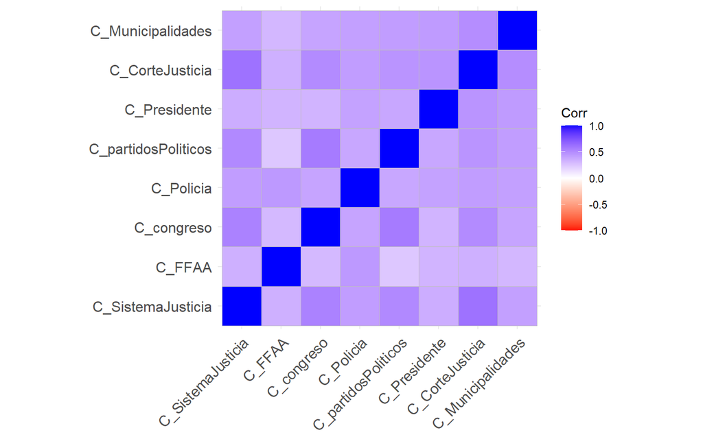

```r
corMatrix=cor(subdata)
library(ggcorrplot)
ggcorrplot(corMatrix,colors = c("#ff0000", "white", "#0000ff"))
```

A grandes rasgos vemos que existe correlación positiva en la matriz por lo que podria seguirse con los siguientes pasos

```r
library(psych)
psych::KMO(subdata)
```

```
## Kaiser-Meyer-Olkin factor adequacy
## Call: psych::KMO(r = subdata)
## Overall MSA =  0.88
## MSA for each item =
##   C_SistemaJusticia              C_FFAA          C_congreso           C_Policia
##                0.87                0.88                0.87                0.89
## C_partidosPoliticos        C_Presidente     C_CorteJusticia   C_Municipalidades
##                0.87                0.90                0.87                0.92
```

El KMO es mayor a 0.7, por lo que el test es muy bueno, la correlación parcial (varianza) nos da luz verde a seguir. Asi mismo el MSA inidivdual de cada variable es muy alta.

```r
cortest.bartlett(corMatrix,n=nrow(subdata))$p.value>0.05
```

```
## [1] FALSE
```

Salió falso a la H0, es decir se cumple HA, entonces, la matriz de correlación y de identidad son diferentes es decir las variables sí están CORRELACIONADAS con las demás y no solo con sigo mismas

Se llevara a cabo APC debido a que queremos ver la varianza total, un buen resumen de la bateria de variables, para que terminen creando el indicador de confianza por vias convencionales (de forma general).

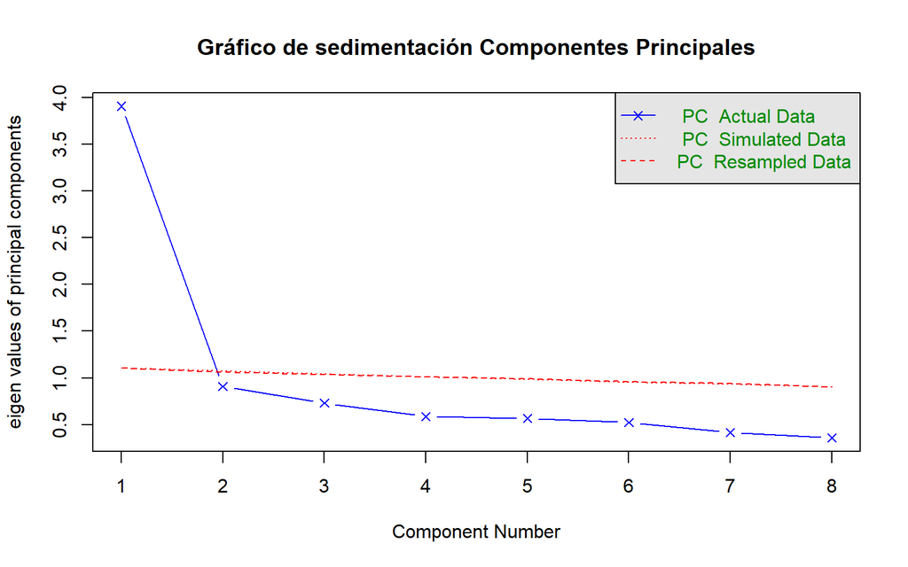

```
## Parallel analysis suggests that the number of factors =  NA  and the number of components =  1
```

```r
fa.parallel(subdata, fm="pa", fa="pc", main = "Gráfico de sedimentación Componentes Principales")
```

R sugiere hacer 1 factor

```r
library("factoextra")
```

```r
library(FactoMineR)
res.pca <-PCA(subdata, graph = FALSE)
eig.val <-get_eig(res.pca)
eig.val
```

```
##       eigenvalue variance.percent cumulative.variance.percent
## Dim.1  3.9091549        48.864436                    48.86444
## Dim.2  0.9100664        11.375830                    60.24027
## Dim.3  0.7303832         9.129790                    69.37006
## Dim.4  0.5869619         7.337024                    76.70708
## Dim.5  0.5650976         7.063720                    83.77080
## Dim.6  0.5245085         6.556356                    90.32716
## Dim.7  0.4167967         5.209959                    95.53712
## Dim.8  0.3570307         4.462884                   100.00000
```

Solamente la primera dimensión es mayor a 1 y explica en su mayoria casi un 50%, es un % por lo que optaremos tan solo por 1 factor

```r
comp1<- pca(subdata,nfactors = 1,rotate = "varimax")
print(comp1$loadings,cutoff = 0.5)
```

```
##
## Loadings:
##                     PC1
## C_SistemaJusticia   0.762
## C_FFAA              0.561
## C_congreso          0.729
## C_Policia           0.681
## C_partidosPoliticos 0.719
## C_Presidente        0.648
## C_CorteJusticia     0.778
## C_Municipalidades   0.690
##
##                  PC1
## SS loadings    3.909
## Proportion Var 0.489
```

**¿Qué variables aportaron más a los componentes?**

```r
sort(comp1$communality)
```

```
##              C_FFAA        C_Presidente           C_Policia   C_Municipalidades
##           0.3150255           0.4196855           0.4643936           0.4766914
## C_partidosPoliticos          C_congreso   C_SistemaJusticia     C_CorteJusticia
##           0.5171543           0.5310665           0.5805941           0.6045441
```

Confianza en la Corte Suprema de Justicia es la variable con mayor porcentaje de varianza total, la que aporta más, es decir da más información al resto de variables.

**¿Qué variables contribuyen a más de un componente?**

```r
sort(comp1$complexity)
```

```
##          C_congreso   C_SistemaJusticia              C_FFAA        C_Presidente
##                   1                   1                   1                   1
##           C_Policia C_partidosPoliticos     C_CorteJusticia   C_Municipalidades
##                   1                   1                   1                   1
```

**¿Qué variables tiene un componente “único” más grande?**

```r
sort(comp1$uniquenesses)
```

```
##     C_CorteJusticia   C_SistemaJusticia          C_congreso C_partidosPoliticos
##           0.3954559           0.4194059           0.4689335           0.4828457
##   C_Municipalidades           C_Policia        C_Presidente              C_FFAA
##           0.5233086           0.5356064           0.5803145           0.6849745
```

El componente único entre las variables, que son únicas y que está presente en menos factores es confianza en las Fuerzas Armadas

```r
comp1_casos=data.frame(comp1$scores)
library(dplyr)
comp1_casos=select(comp1_casos,PC1)
colnames(comp1_casos)=c("Confianza_Via_Convencional")

subdata$Confianza_Convencional<- comp1_casos$Confianza_Via_Convencional

subdata$Confianza_Convencional=as.numeric(subdata$Confianza_Convencional)

library(BBmisc)
subdata$Confianza_Convencional_normalizada = normalize(subdata$Confianza_Convencional,
                                        method = "range",
                                        margin=2, # by column
                                        range = c(0, 100))
```

```r
summary(subdata$Confianza_Convencional_normalizada)
```

```
##    Min. 1st Qu.  Median    Mean 3rd Qu.    Max.
##    0.00   22.37   36.02   36.82   49.47  100.00
```

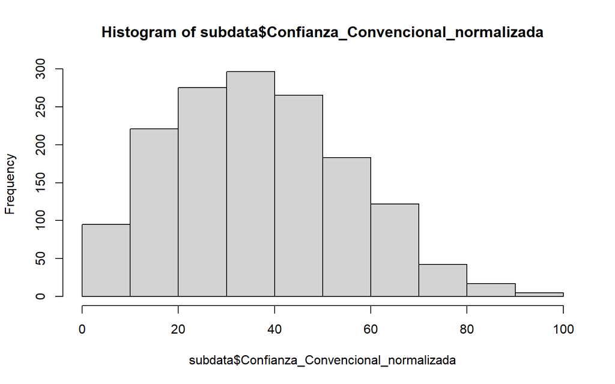

```r
hist(subdata$Confianza_Convencional_normalizada)
```

```r
data$Confiaza_Convencional=subdata$Confianza_Convencional_normalizada
```

Se podrá hacer tecnicas estadisticas con variables Confianza_Convencional_normalizada

##Otras VI que podrían acompañar a Confianza en vias convencionales##

Indice sobre alto o baja legitimidad al sistema político

VI___apoyar al sistema político (B6), respeto por instituciones políticas(B2)

```r
data$legitimidad=(data$b6+data$b2+data$b4)
summary(data$legitimidad)
```

```
##    Min. 1st Qu.  Median    Mean 3rd Qu.    Max.    NA's
##    3.00    9.00   12.00   11.52   15.00   21.00      41
```

```r
data$legitimidad=(data$legitimidad-3)/18*100
summary(data$legitimidad)
```

```
##    Min. 1st Qu.  Median    Mean 3rd Qu.    Max.    NA's
##    0.00   33.33   50.00   47.32   66.67  100.00      41
```

```r
library(car)
library(dplyr)

data$legitimidad=car::recode(data$legitimidad, "0:47=1;47:100=2")
table(data$legitimidad)
```

```
##
##   1   2
## 707 773
```

```r
data$legitimidad=as.ordered(data$legitimidad)
levels(data$legitimidad)=c("Alta legitimidad","Baja legitimidad")
table(data$legitimidad)
```

```
##
## Alta legitimidad Baja legitimidad
##              707              773
```

VI___Creer que los derechos básicos de los ciudadanos están protegidos por el sistema político peruano(B3) sera dicotomica (fast dummies) Se cree o no se cree

```r
table(data$b3)
```

```
##
##   1   2   3   4   5   6   7
## 290 293 342 283 183  71  48
```

```r
data$DDHH=car::recode(data$b3, "1:3=1;3:7=2")
table(data$DDHH)
```

```
##
##   1   2
## 925 585
```

```r
data$DDHH=as.ordered(data$DDHH)
levels(data$DDHH)=c("No cree","Si cree")
table(data$DDHH)
```

```
##
## No cree Si cree
##     925     585
```

```r
library(fastDummies)
data=dummy_cols(data, select_columns = c("DDHH"))
names(data)
```

[output not shown]

[output cut: 65 more lines]

```r
table(data$DDHH_No)
```

```
##
##   0   1
## 585 925
```

```r
table(data$DDHH_Si)
```

```
##
##   0   1
## 925 585
```

```r
table(data$DDHH_NA)
```

```
##
##    0    1
## 1510   11
```

“DDHH_No” “DDHH_Si” “DDHH_NA” 1 se cree no 1 se cree si 1 ni si ni no. NA 0 se cree sí 0 se cree no 0 es Si o no

> Democracia

**Cree o no en la democracia**

¿En su opinion el Perú es una democracia? dem(30)Si o no, es o no es

```r
data$Cree_Dem=car::recode(data$dem30, "1=2;2=1")
table(data$Cree_Dem)
```

```
##
##   1   2
## 497 976
```

```r
data$Cree_Dem=as.ordered(data$Cree_Dem)
levels(data$Cree_Dem)=c("No","Si")
table(data$Cree_Dem)
```

```
##
##  No  Si
## 497 976
```

```r
library(fastDummies)
data=dummy_cols(data, select_columns = c("Cree_Dem"))
names(data)
```

[output not shown]

[output cut: 66 more lines]

“Cree_Dem_NO” “Cree_Dem_SI” “Cree_Dem_NA” 1 NO se cree* 1 si se cree* 1 ni si ni no. NA 0 SI se cree 0 no se cree 0 es Si o no

*Percepción del sentido democratico de los ciudadanos*

**Otra VI que acompañe a creer en la democracia***

En general, ¿usted diría que está muy satisfecho(a), satisfecho(a), insatisfecho(a) o muy insatisfecho(a) con la forma en que la democracia funciona en Perú? pn4. La codificación esta alreves, 1 es muy satisfecho cuando deberia ser muy insatisfecho

(*)RECODIFICAMOS

```r
table(data$pn4)
```

```
##
##   1   2   3   4
##  54 363 854 220
```

```r
data$nivel_satis=car::recode(data$pn4, "4=1;3=2;2=3;1=4")
data$nivel_satis=as.ordered(data$nivel_satis)
levels(data$nivel_satis)=c("Muy insatisfecho","Insatisfecho","Satisfecho","Muy satisfecho")
table (data$nivel_satis)
```

```
##
## Muy insatisfecho     Insatisfecho       Satisfecho   Muy satisfecho
##              220              854              363               54
```

**Otras VI que acompañen a no creer en la democracia**

*Tolerancia a golpes militares, se representará como 1 cuando hay delincuencia y 1 cuando hay corrupcion cuando se use la regresión

- Cuando hay mucha delincuencia

```r
table(data$jc10)
```

```
##
##   1   2
## 385 347
```

```r
table(data$jc13)
```

```
##
##   1   2
## 424 317
```

```r
data$golpe_d=car::recode(data$jc10, "1=2;2=1")
data$golpe_d=as.ordered(data$golpe_d)
levels(data$golpe_d)=c("No se justifica","Si se justifica")
table (data$golpe_d)
```

```
##
## No se justifica Si se justifica
##             347             385
```

```r
data$golpe_c=car::recode(data$jc13, "1=2;2=1")
data$golpe_c=as.ordered(data$golpe_c)
levels(data$golpe_c)=c("No se justifica","Si se justifica")
table (data$golpe_c)
```

```
##
## No se justifica Si se justifica
##             317             424
```

Sobre golpes militares debido a la delincuencia

```r
library(fastDummies)
data=dummy_cols(data, select_columns = c("golpe_d"))
names(data)
```

[output not shown]

[output cut: 109 more lines]

“golpe_d_No” “golpe_d_Si” “golpe_d_NA”

Sobre golpes militares debido a la corrupcion

```r
library(fastDummies)
data=dummy_cols(data, select_columns = c("golpe_c"))
names(data)
```

[output not shown]

[output cut: 111 more lines]

“golpe_c_No” “golpe_c_Si” “golpe_c_NA”

Entonces tolerancia a los golpes militares se representará en la regresión que se haga como golpes_d si, y golpes_c si o 1 en ambos casos, como que si se dan.

*Situación económica personal de los ciudadanos*

¿En cual de los rangos se encuentran los ingresos familiares mensueales?

```r
table(data$q10new)
```

```
##
##   0   1   2   3   4   5   6   7   8   9  10  11  12  13  14  15  16
##  37 147 101  74  78  96 112 135  54  83  74  61  64  76  68  48  84
```

```r
data$rango_ingresos=car::recode(data$q10new, "0:6=1;7:15=2;16=3")
data$rango_ingresos=as.ordered(data$rango_ingresos)
levels(data$rango_ingresos)=c("Clase Baja","Clase media","Clase media-alta")
table(data$rango_ingresos)
```

```
##
##       Clase Baja      Clase media Clase media-alta
##              645              663               84
```

**Otras VI que pueden acompañar**

¿Considera uested que su situación económica actual es mejor, igual o peor que la de hace doce meses?

(*)RECODIFICACION

```r
table(data$idio2)
```

```
##
##   1   2   3
## 248 812 450
```

```r
data$situación_economica=car::recode(data$idio2, "3=1;2=2;1=3")
data$situación_economica=as.ordered(data$situación_economica)
levels(data$situación_economica)=c("Peor","Igual","Mejor")
table(data$situación_economica)
```

```
##
##  Peor Igual Mejor
##   450   812   248
```

**Tendencia política**